# Chapter 8 Problems

## Section 8.1 Fitting a Line, Residuals, and Correlation

### Exercise 8.2

Shown below are two plots of residuals remaining after fitting a linear model to two different sets of data. Describe important features and determine if a linear model would be appropriate for these data. Explain your reasoning.

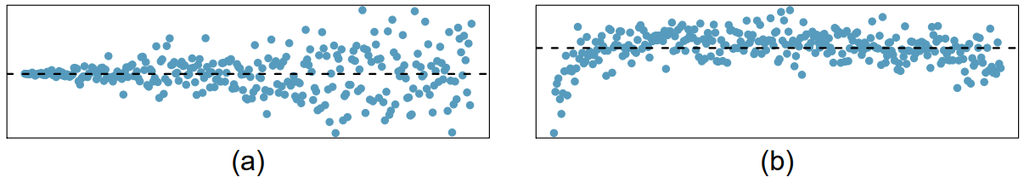

```r
# Answer:

# a) Plot if fan shapped meaning toward the beggining the line is a closer fit but toward the end the varaiton in the residuals is greater with more points scattered outward. Not an appropriate linear fit

# b) Plot seems to have a curvature at the beggining, indicating that the data has some none linear relation within it. Thus, not appropriate to model with a linear relationship.
```

### Exercise 8.5

The two scatterplots below show the relationship between final and mid-semester exam grades recorded during several years for a Statistics course at a university.

1. Based on these graphs, which of the two exams has the strongest correlation with the final exam grade?
2. Can you think of a reason why the correlation between the exam you chose in part (a) and the final exam is higher?

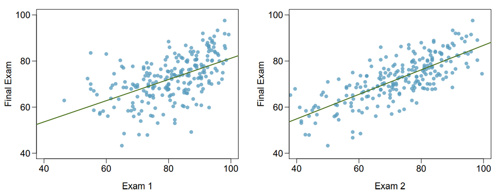

```r
# answer:

# a) Based on the two plots it seems that Exam 2 has a stronger correlation with the final exam grade. The residual variation appears to be smaller than that of Exam 1

# b) One possible explanation is that Exam 2 is a good indicator of improvment in the class which could help a student receive a better grade on their final exam
```

### Exercise 8.13

Researchers studying anthropometry collected body girth measurements and skeletal diameter measurements, as well as age, weight, height and gender for 507 physically active individuals The scatterplot below shows the relationship between height and shoulder girth (over deltoid muscles), both measured in centimeters.

1. Describe the relationship between shoulder girth and height.
2. How would the relationship change if shoulder girth was measured in inches while height remained in centimeters?

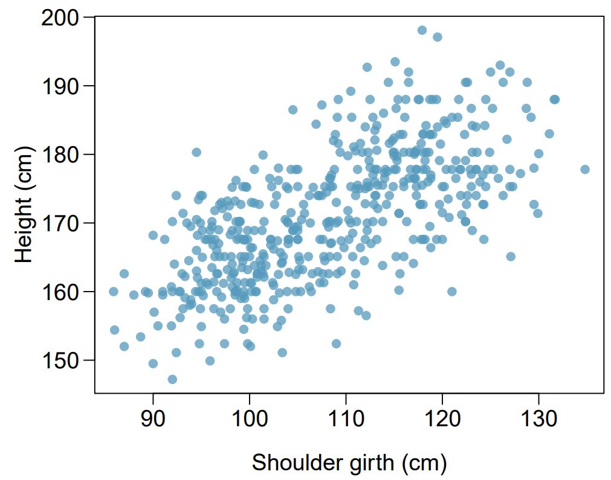

```r
# a) There is a moderately strong, postive relationship between shoulder girth and height.
# b) Changing the units of one or both variable does not affect the form, direction, or shape of the relationship between the two variables. Relationship looks the same just on another scale.
```